# Mapy v 21. století

RVVZ Chaloupky 2025  
Autor: Matěj Man  
Aktualizace: 01. 04. 2025

Papírovým mapám povětšinou již odzvonilo. V běžném životě ustoupily těm elektronickým. Papírové tak plní speciální funkce, které mnohdy při práci s dětským kolektivem oceníme.

**Elektronické mapy**

- navigace v terénu
- plánování, měření, sdílení
- záznam trasy, bodů zájmu

**Papírové mapy**

- navigace s prvkem dobrodružství
- výuka mapových značek, poledníky + rovnoběžky, souřadnice
- severování mapy, práce s buzolou, azimut, měřítko, vzdálenost
- mapy k pokladu
- mapy jako herní plány
- orientační běh

## Mapy online

### ČUZK

Český úřad zeměměřický a katastrální

- [Analýzy výškopisu](https://ags.cuzk.cz/geoprohlizec/)

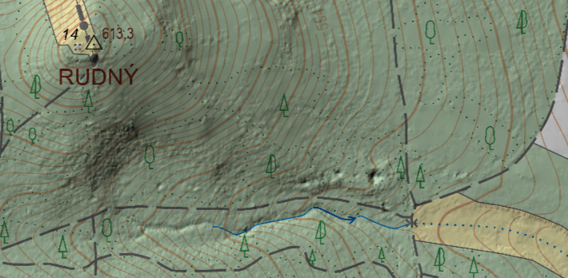

  - Produkty -> ZABAGED výškopis DMR 5g = digitální model reliéfu 5. generace  
    Dobrý pomocník pro hledání terénních zajímavostí - vidí i do lesa  
    Po kliknutí na … v seznamu vrstev vpravo prozkoumat:  
    Režim prolnutí - násobit  
    Rastrové funkce - GrayscaleHillshadeZ10 (10x znásobené převýšení)
  - Produkty -> Archivní ortofoto (1998 - 2022)
- [Archivní mapy](https://ags.cuzk.gov.cz/archiv/)

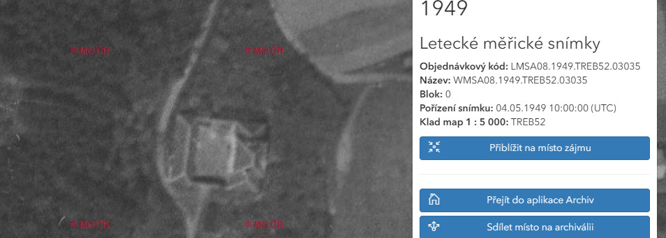

  - Archivní mapy - Müllerova mapa Čech a Moravy, Císařské otisky
  - Letecké měřické snímky (1936 - 2024)  
    vlevo nahoře - vyhledat archiválie zadáním místa v mapě  
    Klik do mapy - vlevo se zobrazí jednotlivé snímky  
    Po kliknutí na snímek - přiblížit na místo zájmu  
    Území ČR je pokryté nespojitě

### ČGS

Česká geologická služba

- [významné geologické lokality](https://mapy.geology.cz/geologicke_lokality/)
- [Důlní díla a poddolování](https://mapy.geology.cz/dulni_dila_poddolovani/)

[figure not shown]

- [Vrtná prozkoumanost](https://mapy.geology.cz/vrtna_prozkoumanost/)

[figure not shown]